# Week2-simpleMD

## 데이터프레임

데이터프레임은 행렬과 유사하지만 다소 다르다. 행렬은 수학적인 개념이라면, 데이터프레임은 조금 더 데이터를 담아두는 공간 같은 느낌이다. 그래서 행렬의 각 성분에는 character와 numeric이 혼재할 수 없지만, 데이터프레임 안에서는 가능하다.

### 데이터프레임 생성

```r
name = c('Kim', 'Park', 'Lee')
age = c(25, 23, 21)
male = c(T, F, T)
X = data.frame(name, age, male, stringsAsFactors = F) # character를 factor로 처리할건지. default는 R 4.0부터 F
X
```

```
##   name age  male
## 1  Kim  25  TRUE
## 2 Park  23 FALSE
## 3  Lee  21  TRUE
```

```r
cbind(name, age, male) # 행렬은 각각의 형태를 캐릭터로 통일해버렸다.
```

```
##      name   age  male
## [1,] "Kim"  "25" "TRUE"
## [2,] "Park" "23" "FALSE"
## [3,] "Lee"  "21" "TRUE"
```

만들어진 데이터프레임을 확인해보자. 다음의 함수는 데이터를 확인할 때 자주 쓴다. 3회차에는 더 좋은 함수를 소개하겠다.

```r
str(X)
```

```
## 'data.frame':    3 obs. of  3 variables:
##  $ name: chr  "Kim" "Park" "Lee"
##  $ age : num  25 23 21
##  $ male: logi  TRUE FALSE TRUE
```

```r
summary(X)
```

```
##      name                age        male
##  Length:3           Min.   :21   Mode :logical
##  Class :character   1st Qu.:22   FALSE:1
##  Mode  :character   Median :23   TRUE :2
##                     Mean   :23
##                     3rd Qu.:24
##                     Max.   :25
```

```r
dim(X)
```

```
## [1] 3 3
```

### 데이터프레임 인덱싱

데이터프레임의 인덱싱은 행렬과 유사하지만 다르다. 데이터프레임은 기본적으로 list의 하위개념이기 때문에…하지만 list자체를 우리가 다룰 일이 많지 않아서 제외했다. 아무튼 확인해보자.

```r
X[1] # 데이터프레임
```

```
##   name
## 1  Kim
## 2 Park
## 3  Lee
```

```r
X[1:2] # 데이터프레임
```

```
##   name age
## 1  Kim  25
## 2 Park  23
## 3  Lee  21
```

```r
X[[1]] # 벡터
```

```
## [1] "Kim"  "Park" "Lee"
```

```r
X[, 1:2]
```

```
##   name age
## 1  Kim  25
## 2 Park  23
## 3  Lee  21
```

```r
X[1:2, ]
```

```
##   name age  male
## 1  Kim  25  TRUE
## 2 Park  23 FALSE
```

```r
# 숫자로 인덱싱하는 것에는 차이가 없다.

X$name # 열 이름을 인덱싱하는것이 편리하다.
```

```
## [1] "Kim"  "Park" "Lee"
```

```r
X$name = c('Tim', 'Lee', 'Lim')
X
```

```
##   name age  male
## 1  Tim  25  TRUE
## 2  Lee  23 FALSE
## 3  Lim  21  TRUE
```

### 여러가지 활용

데이터를 다루다보면 결측값이 있기 마련이다. 이런 값을 대체하거나 삭제해보자.

```r
X = data.frame(x1 = c(6, 3, NA, 3, NA), x2 = 1:5, x3 = 7:11)
complete.cases(X)
```

```
## [1]  TRUE  TRUE FALSE  TRUE FALSE
```

```r
X[complete.cases(X), ] # 결측값이 있는 행 제거
```

```
##   x1 x2 x3
## 1  6  1  7
## 2  3  2  8
## 4  3  4 10
```

```r
X[is.na(X)] = 0; X # 결측값을 0으로 대체
```

```
##   x1 x2 x3
## 1  6  1  7
## 2  3  2  8
## 3  0  3  9
## 4  3  4 10
## 5  0  5 11
```

데이터에 접근해보자. 우리가 원하는 데이터만 얻고 싶어서 인덱싱을 통해 가져올 것이다.

```r
data = mtcars
colnames(data)
```

```
##  [1] "mpg"  "cyl"  "disp" "hp"   "drat" "wt"   "qsec" "vs"   "am"   "gear"
## [11] "carb"
```

```r
# 우리가 mpg가 25이상, gear가 4단 이상인 자동차의 정보를 얻고 싶다면?
(data$mpg >= 25) & (data$gear >= 4)
```

```
##  [1] FALSE FALSE FALSE FALSE FALSE FALSE FALSE FALSE FALSE FALSE FALSE FALSE
## [13] FALSE FALSE FALSE FALSE FALSE  TRUE  TRUE  TRUE FALSE FALSE FALSE FALSE
## [25] FALSE  TRUE  TRUE  TRUE FALSE FALSE FALSE FALSE
```

```r
data[(data$mpg >= 25) & (data$gear >= 4), ]
```

```
##                 mpg cyl  disp  hp drat    wt  qsec vs am gear carb
## Fiat 128       32.4   4  78.7  66 4.08 2.200 19.47  1  1    4    1
## Honda Civic    30.4   4  75.7  52 4.93 1.615 18.52  1  1    4    2
## Toyota Corolla 33.9   4  71.1  65 4.22 1.835 19.90  1  1    4    1
## Fiat X1-9      27.3   4  79.0  66 4.08 1.935 18.90  1  1    4    1
## Porsche 914-2  26.0   4 120.3  91 4.43 2.140 16.70  0  1    5    2
## Lotus Europa   30.4   4  95.1 113 3.77 1.513 16.90  1  1    5    2
```

# 기본 함수와 플랏

R의 기본적인 함수정의와 루프문, 그리고 플랏을 살펴본다.

## Function

파이썬에서는 `def`로 함수를 정의했는데, R에서는 `function`으로 정의한다.

```r
average = function(x) {
  value = sum(x) / length(x)
  return(value) # return이 존재해야하는 경우가 대부분
}
y = c(1, 2, 3, 4, 5)
average(y)
```

```
## [1] 3
```

## for loop

`for (k in x) {do something}`

- {}안에서는 반복적인 작업을 수행
- 반복횟수 = length of x
- `break` : early stopping
- `next` : 다음 반복으로 넘어감

```r
x = c(5, 6, 10, 7, 12)
z = NULL
for (k in x){
  z = c(z, k+3)
}
z
```

```
## [1]  8  9 13 10 15
```

```r
z <- NULL
for (k in x) {
  z <- c(z, k + 3)
  if (k >= 10) break
}
z
```

```
## [1]  8  9 13
```

```r
z <- NULL
for (k in x) {
  if (k >= 10) next
  z <- c(z, k + 3)
}
z
```

```
## [1]  8  9 10
```

## while & repeat loop

`while (condition0) {do something}`

- {}은 반복할 내용, condtion이 True일 때 까지
- `break` : early stopping

`repeat{}`

- `while`과 비슷한데, `repeat`은 종료와 관련한 조건이 없음
- 종료를 위해서는 `break`가 달려있어야함.

```r
x <- 0
while (x < 5){
  x <- x + 1
}
x
```

```
## [1] 5
```

```r
x <- 0
while (x < 5){
  x <- x + 1
  if (x > 3) break
}
x
```

```
## [1] 4
```

```r
x <- 0
repeat {
  x <- x + 1
  if (x >= 5) break
}
x
```

```
## [1] 5
```

## ifelse

`ifelse`는 정말 많이 쓰인다. 보통 데이터 전처리할때 재범주화하는 경우 많이 사용했다. 예를 들어 나이가 13, 26, 80, 50, … 이렇게 있는데, 이를 청소년, 청년, 장년, 중년, 노년 등으로 재범주화할 때 사용하기 편하다.

먼저 `if`문 먼저 보고, `ifelse`를 확인하자.

```r
r <- 3
if (r==4) {
  x <- 1
} else {
  x <- 3
  y <- 5
}
x
```

```
## [1] 3
```

```r
y
```

```
## [1] 5
```

```r
r <- 3
if (r==4) {
  x <- 1
} else if (r == 3) {
  x <- 3
  y <- 5
} else {
  x = 7
}
x
```

```
## [1] 3
```

```r
y
```

```
## [1] 5
```

`ifelse`를 확인하자.

```r
ifelse(c(3, 5, 7, 9, 11) > 3, 'a', 'b')
```

```
## [1] "b" "a" "a" "a" "a"
```

```r
ifelse(c(3, 5, 7, 9, 11) > 7, 'a', ifelse(c(3, 5, 7, 9, 11) > 4, 'b', 'c'))
```

```
## [1] "c" "b" "b" "a" "a"
```

## Plot

plot 함수를 통해 그래프를 그리고 시각화를 할 수 있다.

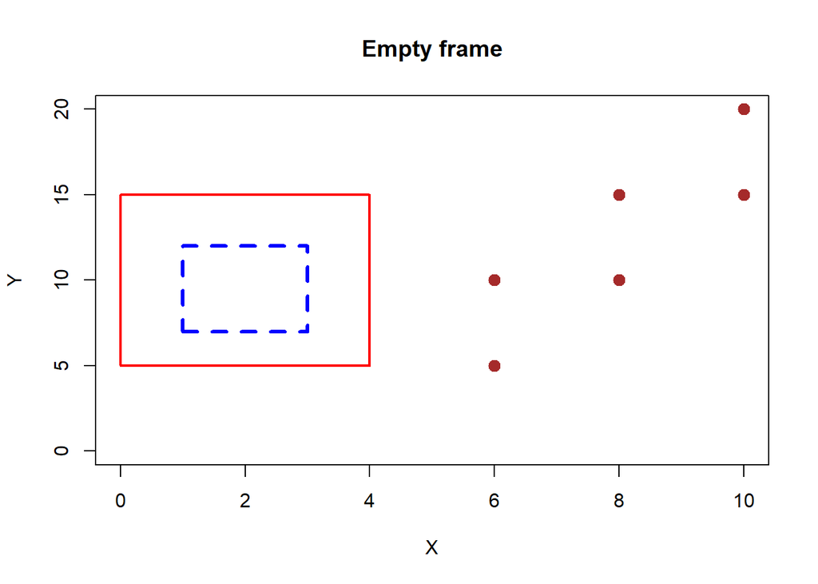

```r
plot(c(0, 10), c(0, 20), type = "n", xlab = "X", ylab = "Y",
     main = "Empty frame")
points(c(6, 8, 10, 6, 8, 10), c(5, 10, 15, 10, 15, 20),
       col = "brown", cex = 2, pch = 20)
lines(c(0, 4, 4, 0, 0), c(5, 5, 15, 15, 5), col = "red", lwd = 2)
lines(c(1, 3, 3, 1, 1), c(7, 7, 12, 12, 7), col = "blue", lwd = 3, lty = 2)
```

산점도를 그려보자

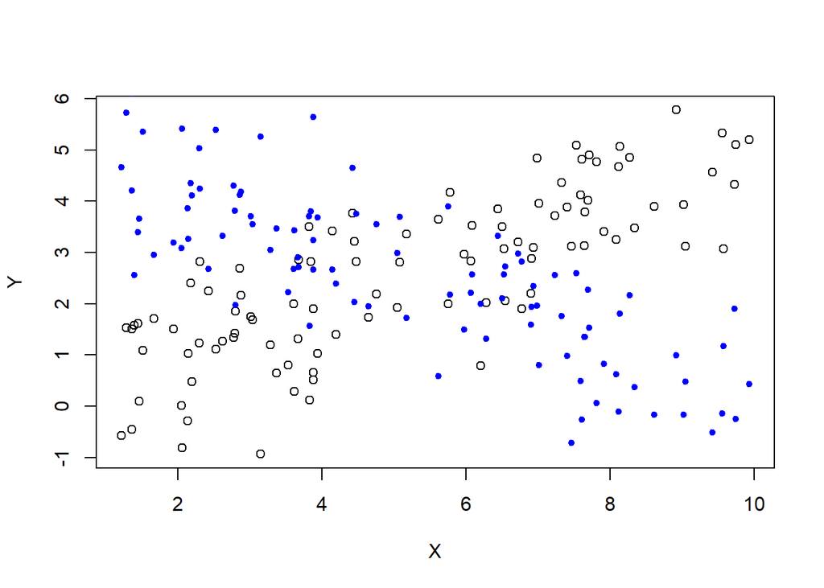

```r
n <- 100
x <- runif(n, 1, 10)
y1 <- 0.5 * x + rnorm(n)
y2 <- 5 - 0.5 * x + rnorm(n)
plot(x, y1, xlab = "X", ylab = "Y")
points(x, y2, col = "blue", pch = 20)
```

선 그래프를 그려보자

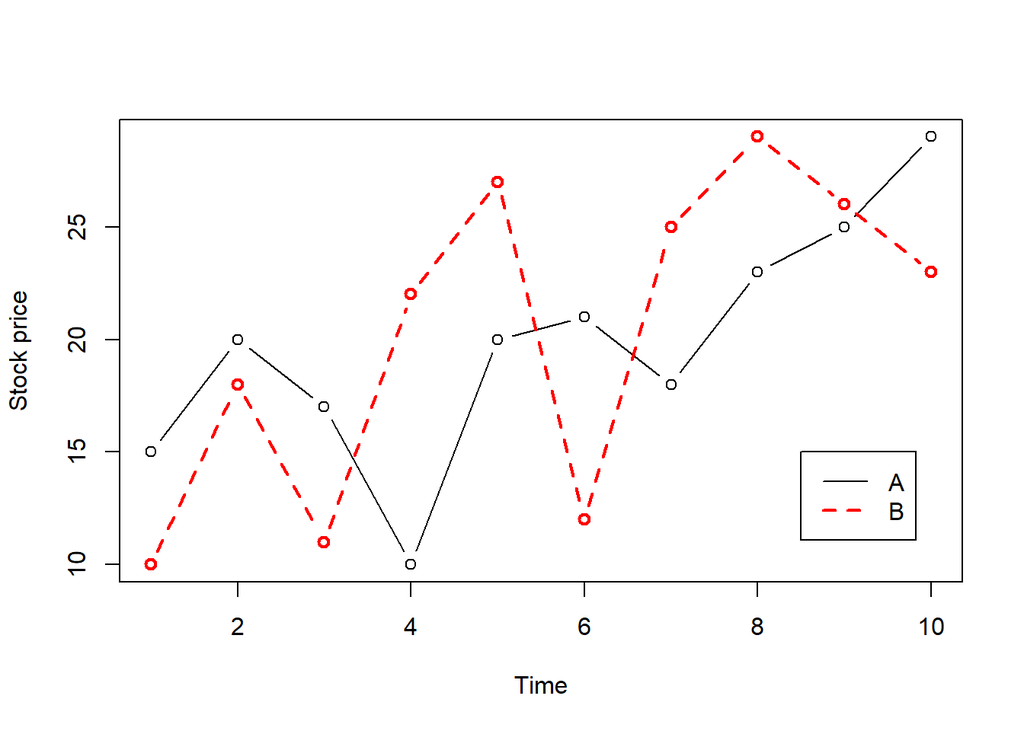

```r
Time <- 1:10
stock1 <- c(15, 20, 17, 10, 20, 21, 18, 23, 25, 29)
stock2 <- c(10, 18, 11, 22, 27, 12, 25, 29, 26, 23)
plot(Time, stock1, type = "b", xlab = "Time", ylab = "Stock price")
lines(Time, stock2, type = "b", col = "red", lwd = 2, lty = 2)
legend(8.5, 15, c("A", "B"), col = c("black", "red"),
       lty = c(1, 2), lwd = c(1, 2))
```

막대그래프를 그려보자

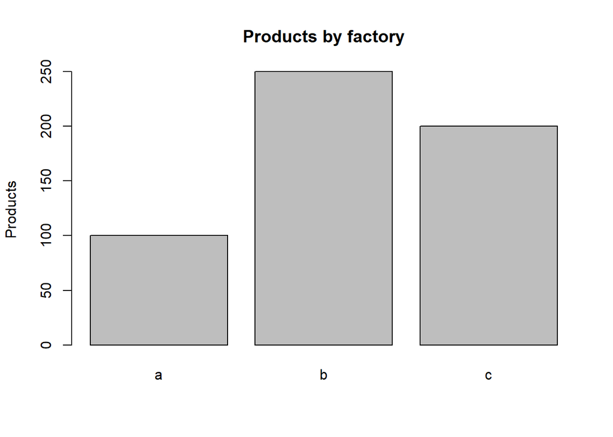

```r
x <- c(100, 250, 200)
barplot(x, names.arg = c("a", "b", "c"), ylab = "Products", main = "Products by factory")
```

히스토그램을 그려보자

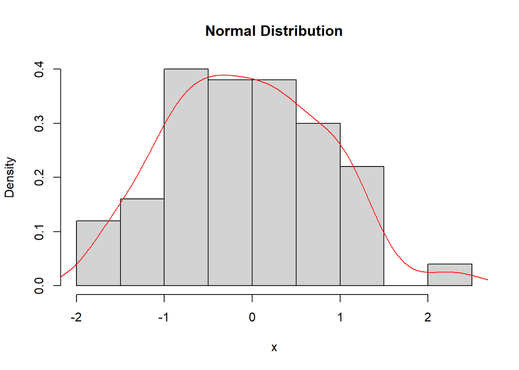

```r
x <- rnorm(100)
hist(x, main = "Normal Distribution", freq = F)
lines(density(x), col = "red")
```

박스플랏을 그려보자

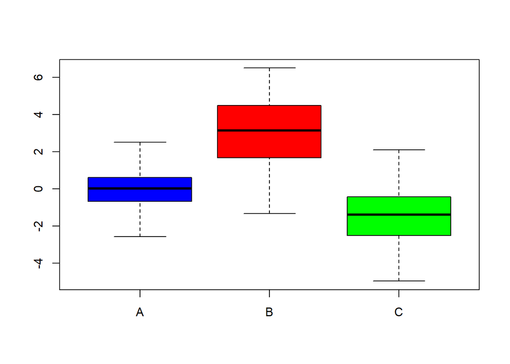

```r
x <- rnorm(100)
y <- rnorm(100, mean = 3, sd = 2)
z <- rnorm(100, mean = -1, sd = 1.5)
boxplot(x, y, z, names = c("A", "B", "C"), col = c("blue", "red", "green"))
```

하지만 이런 기본 플랏들은 잘 사용하지 않는다. 이런 시각화는 대충 확인해보는 의미도 있지만, 다른 사람들에게 예쁘게 보여주려는 목적도 있기 때문에, 기본 플랏은 문법은 정말 단순하지만 예쁘지가 않다. 그래서 R에서 많이 쓰이는 그래픽 패키지는 `ggplot2`로 `grammar of graphics`라는 엄청난 이름을 가진 패키지를 사용하게 된다. 파이썬의 `matplotlib, seaborn`보다 훨씬 문법적으로도 간편하고, 플랏에 소소한 기능들을 추가하는 것이 상대적으로 매우 쉽다.

하지만 ggplot은 따로 다룰 시간이 없기 때문에… 관심있으신 분들은 `ggplot2 examples`라고 구글에 치면 정말 많은 예제가 나옵니다!

# Statistics

## 기본함수

- exp(): Exponential function with base e.
- log(): Natural log.
- log10(): Logarithm with base 10.
- sqrt(): square root.
- abs(): absolute value.
- sin(), cos(), tan(): Trigonometric functions.
- min(), max(): Minimum / maximum value within a vector.
- which.min(), which.max(): Index of the minimal / maximal element of a vector.

```r
x <- c(6, 3, 4, 1, 5)
min(x)
```

```
## [1] 1
```

```r
max(x)
```

```
## [1] 6
```

```r
which.min(x)
```

```
## [1] 4
```

## 확률변수

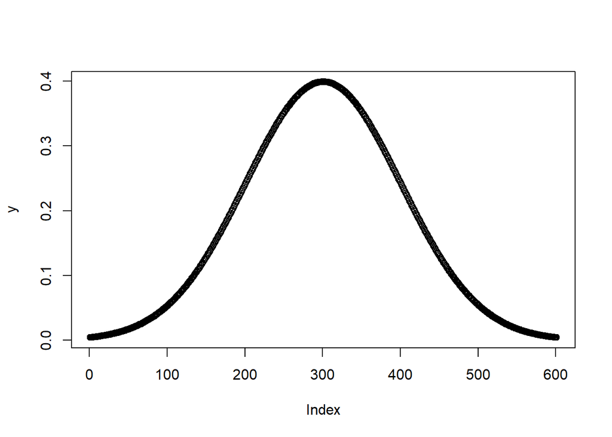

```r
x <- seq(from = -3, to = 3, by = 0.01)
y <- dnorm(x, mean = 0, sd = 1, log = FALSE)
plot(y)
```

```r
x <- rbinom(2000, size = 50, prob = 1/5)
mean(x)
```

```
## [1] 10.002
```

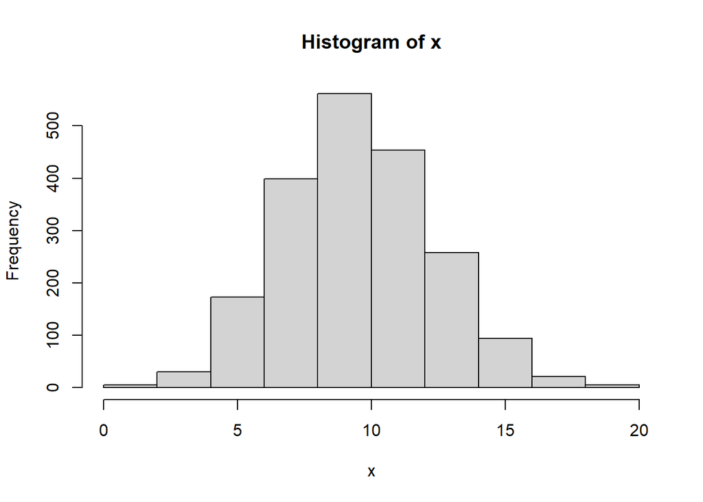

```r
hist(x)
```

```r
pbinom(2, 10, 0.3) - pbinom(1, 10, 0.3) # P(X <= 2) - P(X <= 1) == P(X == 2)
```

```
## [1] 0.2334744
```

```r
qnorm(0.975, 0, 1)
```

```
## [1] 1.959964
```

```r
pnorm(1.645, 0, 1)
```

```
## [1] 0.9500151
```